# Estudis d'Informàtica, Multimedia i Telecomunicacions

# Mineria de dades: PRA2 - Modelatge per a un joc de dades

Maig 2021

# 1 Introducció

## 1.1 Presentació

Aquesta pràctica cobreix de manera transversal l’assignatura.

Les Pràctiques 1 i 2 de l’assignatura es plantegen d’una forma conjunta de manera que la Pràctica 2 serà continuació de la 1.

L’objectiu global de la **Pràctica 2** és d’extreure coneixements i de comparar les diferents solucions aplicant tot l’après mitjançant els algorismes de clustering, associació i classificació.

## 1.2 Competències

Les competències que es treballen en aquesta prova són:

- Ús i aplicació de les TIC en l’àmbit acadèmic i professional.
- Capacitat per a innovar i generar noves idees.
- Capacitat per a avaluar solucions tecnològiques i elaborar propostes de projectes tenint en compte els recursos, les alternatives disponibles i les condicions de mercat.
- Conèixer les tecnologies de comunicacions actuals i emergents així com saber-les aplicar convenientment per a dissenyar i desenvolupar solucions basades en sistemes i tecnologies de la informació.
- Aplicació de les tècniques específiques d’enginyeria del programari en les diferents etapes del cicle de vida d’un projecte.
- Capacitat per a aplicar les tècniques específiques de tractament, emmagatzematge i administració de dades.
- Capacitat per a proposar i avaluar diferents alternatives tecnològiques per a resoldre un problema concret.

## 1.3 Objetius

La correcta assimilació de tots els aspectes treballats durant el semestre. En aquesta pràctica abordem un cas real de mineria de dades on hem de posar en joc tots els conceptes treballats. Cal treballar tot el cicle de vida del projecte. Des de l’objectiu del projecte fins a la implementació del coneixement trobat passant per la preparació, neteja de les dades, coneixement de les dades, generació del model, interpretació i avaluació.

## 1.4 Descripció de la PRA a realitzar

La pràctica consta d’exercicis en els quals l’estudiant aplicarà alguns dels mètodes supervisats i no supervisats apresos durant el semestre.

## 1.5 Recursos Bàsics

Material docent proporcionat per la UOC.

## 1.6 Criteris de valoració

**Exercicis pràctics**

Per a totes les PRA és necessari documentar en cada apartat de l’exercici pràctic que s’ha fet i com s’ha fet.

## 1.7 Format i data d’entrega

El format d’entrega és: **usernameestudiante-PRA2** *.Rmd* i el **output generat** en un d’aquests formats html/*doc/docx/odt/pdf*.

Data de lliurament: **16/06/2021**

S’ha de lliurar la PRA en la bústia de lliuraments de l’aula en format comprimit que inclou els fitxers: - executable - output - el dataset seleccionat o en defecte d’això indicar la ruta per a la seva descàrrega en l’executable.

## 1.8 Nota: Propietat intel·lectual

> Sovint és inevitable, en produir una obra multimèdia, fer ús de recursos creats per terceres persones. És per tant comprensible fer-ho en el marc d’una pràctica dels estudis d’Informàtica, Multimèdia i Telecomunicació de la UOC, sempre que això es documenti clarament i no suposi plagi en la pràctica.

> Per tant, en presentar una pràctica que faci ús de recursos aliens, s’ha de presentar juntament amb ella un document en el que es detallin tots ells, especificant el nom de cada recurs, el seu autor, el lloc on es va obtenir i el seu estatus legal: si l’obra aquesta protegida pel copyright o s’acull a alguna altra llicència d’ús (Creative Commons, llicència GNU, GPL …). L’estudiant haurà d’assegurar-se que la llicència no impedeix específicament el seu ús en el marc de la pràctica. En cas de no trobar la informació corresponent haurà d’assumir que l’obra aquesta protegida per copyright.

> Haureu, a més, adjuntar els fitxers originals quan les obres utilitzades siguin digitals, i el seu codi font si correspon.

# 2 Enunciat

Com a continuació de l’estudi iniciat en la pràctica 1, procedim a **aplicar models analítics** sobre el joc de dades seleccionat i preparat. En aquesta pràctica 2 s’aconsella d’adjuntar els “chunks” de la part de preparació prèvia, exemple (neteja, discretizació, normalització, PCA/*SVD etc.), o en defecte d’això carregar només les dades ja preparades

D’aquesta manera es demana a l’estudiant que completi els següents passos:

1. Aplicar un model **no supervisat** i basat en el concepte de distància, sobre el joc de dades.
2. Aplicar de nou el model anterior, però usant una **mètrica diferent** i comparar els resultats.
3. Raonar si té sentit aplicar al dataset seleccionat, un mètode de **generació de regles d’associació**. En cas afirmatiu, realitzar tal procés i explicar els resultats. En cas contrari, reformula el problema perquè sí que el tingui.
4. Aplicar un model de generació de regles a partir de **arbres de decisió** sense i amb opcions de poda i comparar els resultats.
5. Aplicar una millora amb **tècniques de boosting** i comparar el resultat amb l’anterior.
6. Identificar eventuals **limitacions** del dataset seleccionat i **analitzar els riscos** per al cas d’ús.
7. (Punt comú per a tots els exercicis) - En tots els punts anteriors es demana a l’estudiant, a més d’aplicar els diferents mètodes, d’analitzar correctament el problema, **detallar de manera exhaustiva** ressaltant el perquè i com s’ha realitzat, incloent elements visuals, explicant els resultats, realitzar les comparatives oportunes amb les seves conclusions.

# 3 Criteris d’avaluació

- Exercici 1 (25%)
  - Es genera un model no supervisat.
  - S’analitzen, mostren i comenten les mesures de qualitat del model generat.
  - Es comenten les conclusions.
- Exercici 2 (10%)
  - Es genera de nou el model no supervisat anterior, però usant una mètrica de distància diferent.
  - Es mostren i comenten les mesures de qualitat del model generat.
  - Addicionalment es comparen els dos models no supervisats amb mètriques de distància diferents.
  - Es comenten les conclusions.
- Exercici 3 (10%)
  - Es representa, analitza i comenta un exemple de regles d’associació aplicat al dataset seleccionat, o en defecte d’això es reformula el problema (mínim de 250 paraules).
  - Es comenten les conclusions.
- Exercici 4 (25%)
  - Es generen regles i es comenten i interpreten les més significatives.
  - Extraiem les regles del model en format text i gràfic.
  - Addicionalment es genera matriu de confusió per a mesurar la capacitat predictiva de l’algorisme.
  - Es comparen i interpreten els resultats sense i amb opcions de poda, explicant els avantatges i inconvenients del model generat respecte a un altre mètode de construcció.
  - S’avalua la taxa d’error en cada nivell d’arbre, l’eficiència en classificació (en les fases de training, validació i test) i la comprensibilitat.
  - Es comenten les conclusions.
- Exercici 5 (10%)
  - S’aplica una millora amb tècnica de boosting.
  - Es detalla, comenta i avalua la qualitat de classificació.
  - Es comparen i comenten els resultats de manera exhaustiva amb l’anterior mètode de construcció.
- Exercici 6 (10%)
  - Identifica quines possibles limitacions tenen les dades que has seleccionat per a obtenir conclusions amb els models (supervisat i no supervisat)
  - S’identifiquen possibles riscos de l’ús del model (mínim 250 paraules).
- Consideració general (10%)
  - Es presenta el codi i és fàcilment reproduïble.
  - Es detalla cada pregunta de manera correcta, mostrant el codi, comentant com s’ha fet i perquè s’ha fet, comparant els resultats i/o indicant altres alternatives al problema indicat.
  - Es mostren les conclusions en cada apartat.
  - S’indiquen eventuals citacions bibliogràfiques, fonts internes/externes i materials de recerca.

# 4 Recursos de programació

- Incloem en aquest apartat una llista de recursos de programació per a mineria de dades on podreu trobar exemples, idees i inspiració:
  - [Material addicional del llibre: Mineria de dades Models i Algorismes](http://oer.uoc.edu/libromd/)
  - [Espai de recursos UOC per a ciència de dades](http://datascience.recursos.uoc.edu/es/)
  - [Cercador de codi R](https://rseek.org/)
  - [Col·lecció de cheatsheets en R](https://rstudio.com/resources/cheatsheets/)
  - [Introducing Clustering II: Clustering Algorithms](https://gameanalytics.com/blog/introducing-clustering-ii-clustering-algorithms/)
  - [Clustering Algorithms](https://developers.google.com/machine-learning/clustering/clustering-algorithms)
  - [K-means Cluster Analysis](https://uc-r.github.io/kmeans_clustering#silo)

# 5 Implementació

## 5.1 Càrrega de les dades i llibreries

Carregem llibreries.

```r
#https://cran.r-project.org/web/packages/ggplot2/index.html
if (!require('ggplot2')) install.packages('ggplot2'); library('ggplot2')
# https://cran.r-project.org/web/packages/dplyr/index.html
if (!require('dplyr')) install.packages('dplyr'); library('dplyr')
if (!require(cluster)) install.packages(cluster);library(cluster)
if(!require(MVA)) install.packages("MVA"); library(MVA)
if(!require(tidyr)) install.packages("tidyr");library(tidyr)
if(!require(cluster)) install.packages("cluster"); library(cluster)
if(!require(plyr)) install.packages("plyr"); library(plyr)
if(!require(readr)) install.packages("readr"); library(readr)
```

Carregem tots els arxius de dades en un únic DataFrame.

```r
#IMPORT DATA - src: https://opendata-ajuntament.barcelona.cat/data/ca/dataset/est-atur-pes

#List of all files - https://datascienceplus.com/how-to-import-multiple-csv-files-simultaneously-in-r-and-create-a-data-frame/
mycsvfiles = list.files(pattern="*.csv", full.names=TRUE)
mycsvfiles
```

```
##  [1] "./2012_atur.csv" "./2013_atur.csv" "./2014_atur.csv" "./2015_atur.csv"
##  [5] "./2016_atur.csv" "./2017_atur.csv" "./2018_atur.csv" "./2019_atur.csv"
##  [9] "./2020_atur.csv" "./2021_atur.csv"
```

```r
#DataFrame creation with all data from files list
datafromcsv = ldply(mycsvfiles, read_csv)
#Setting headers
colnames(datafromcsv) <- c("Any", "Mes", "CodiDistricte", "NomDistricte", "CodiBarri", "NomBarri", "Poblacio", "PesAtur")

#Filter by only numeric data
numericData <- datafromcsv %>% select(is.numeric)
#Number of rows
numericRows = dim(numericData)[1]
```

## 5.2 Model no supervistat

Els models no supervisats són algorismes que apliquen regles d’agregació per tal d’intentar trobar una estructura dins d’un conjunt de dades no etiquetades. Un dels models més coneguts en la funció de detectar la semblança entre objectes d’un conjunt de dades és **k-means**. Aquest algorisme forma part de la família del *Centroid-based clustering* que agrupa elements a través del càlcul de distàncies entre els centres dels clústers. K-means és tan extensament utilitzat, ja que és molt eficient, efectiu i simple tot i ser bastant sensible a les condicions inicials i els outliers. Normalment el càlcul de distàncies s’efectua a través de la distància euclidiana.

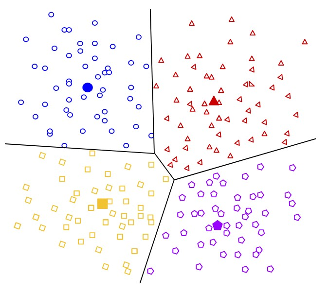

Centroid-based clustering example

Abans de realitzar la implementació d’aquest algorisme, comprovarem com es distribueixen els valors del atur en cada un dels barris al llarg del temps per tal de considerar si és una bona opció plantejar, que cada un dels barris té un comportament particular en la relació ‘població activa - atur’.

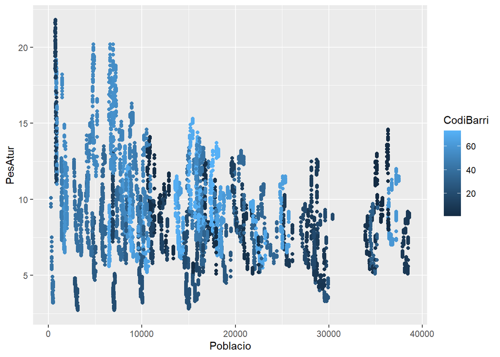

```r
#List of name that we are going to use and filter by these fields
barriPoblAturNames <- c("CodiBarri", "Poblacio", "PesAtur")
barriPoblAtur <- select(numericData, barriPoblAturNames)

#Point plot by using the relation poblation-unemployment
pobAturPlot <- ggplot(barriPoblAtur, aes(Poblacio, PesAtur)) + geom_point(aes(color=CodiBarri))
pobAturPlot
```

A través del plot anterior poden visualitzar que cada un dels barris tendeix a seguir una tendència particular que es veu reflectida en una col·lecció de punts verticals que descriu la fluctuació de l’atur per cada un d’aquests, juntament amb una variació molt lleugera en termes de població. És per això que té molt de sentit aplicar un model no supervisat sobre aquest conjunt de dades per tal de poder confirmar aquest comportament i detectar els diferents conjunts d’elements semblants dins el nostre domini. Per a realitzar aquesta comprovació utilitzarem diferents tècniques i criteris.

### 5.2.1 Average Silhouette Method

El primer mètode que utilitzarem per a aproximar el valor òptim corresponent al nombre de clústers pel nostre conjunt de dades és el de la *silueta mitjana*. Aquest mètode determina que encertat és situar cada un dels objectes a un valor **k** de clústers, calculant el valor mitjà per un conjunt de valors diferents **k**. Un valor mitjà alt de la silueta indica una bona agrupació, mentre que un valor baix indica el contrari. Inicialment aplicarem l’algorisme **kmeans** amd diferents valors **k**. Amb els càlculs resultants obtindrem la silueta mitjana per cada valor **k**. Finalment observarem els resultats en format gràfic i seleccionarem el valor més alt.

```r
# Compute and plot wss for k = 2 to k = 73
k.values <- 2:73

# Extract avg silhouette for 2-73 clusters
result <- rep(0,73)
for( i in k.values ){
  km.res <- kmeans(barriPoblAtur[1:3], centers = i)
  sk <- silhouette(km.res$cluster, dist(barriPoblAtur[1:3]))
  result[i]<-mean(sk[, 2])
}
#Print max value
print(max(result))
```

```
## [1] 38.00074
```

```r
#Print the index of max value
which.max(result)
```

```
## [1] 73
```

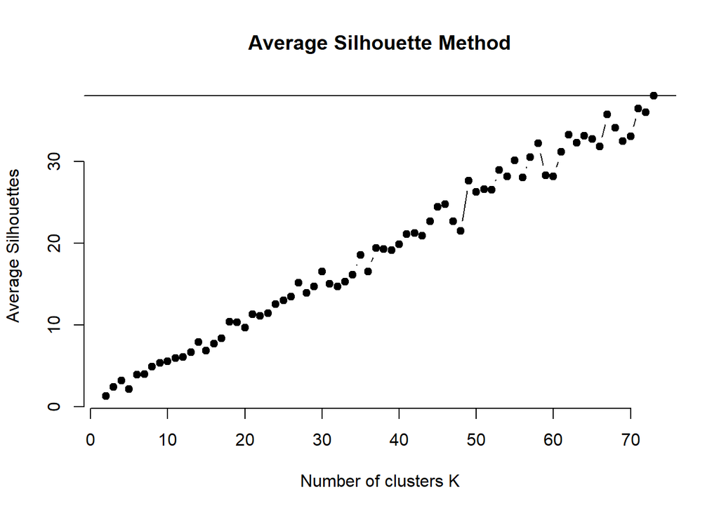

```
## integer(0)
```

```r
#Plot Average Silhouette
plot(2:73, result[2:73],
    type = "b", pch = 19, frame = FALSE,
    main = "Average Silhouette Method",
    xlab = "Number of clusters K",
    ylab = "Average Silhouettes") +
abline(h = max(result))
```

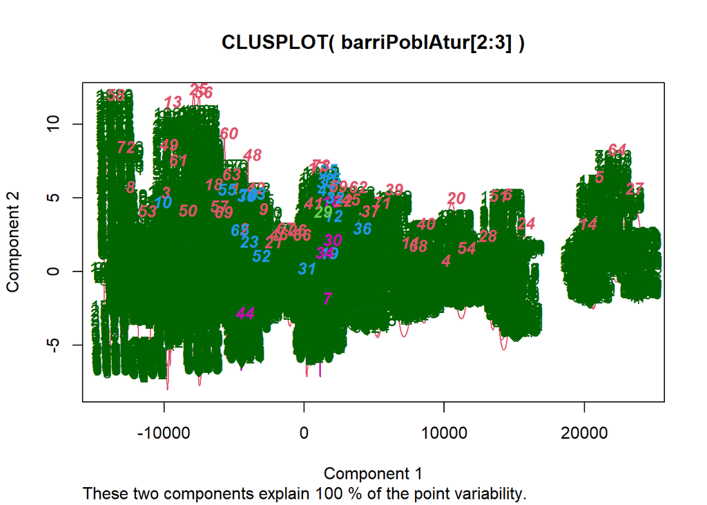

```r
#Clusters distribution plot
clusplot(barriPoblAtur[2:3], km.res$cluster, color=TRUE, shade=TRUE, labels=2, lines=0)
```

*Warning: Aquest valor és variable degut al fet que ens trobem executant l’algorisme kmeans que té un factor aleatori.*

Els resultats obtinguts ens indiquen que el valor òptim **k** correspon a 73, ja que és el valor més repetit al llarg de les execucions. Aquest valor confirma les nostres prediccions prèvies, tot i això aplicarem un segon mètode per poder comparar resultats.

### 5.2.2 Calinski-Harabasz Index

El segon mètode que utilitzarem és el criteri **Calinski-Harabasz**. Aquest mètode igual que l’anterior, ens permet determinar el valor *k* òptim del nostre conjunt de dades mitjançant l’execució de l’algorisme **kmeans**.

```r
if(!require(fpc)) install.packages(fpc); library(fpc)

#Calinski-Harabasz criterion computation
fit_ch  <- kmeansruns(barriPoblAtur, krange = 1:73, criterion = "ch")

#Print best K value
print(fit_ch$bestk)
```

```
## [1] 72
```

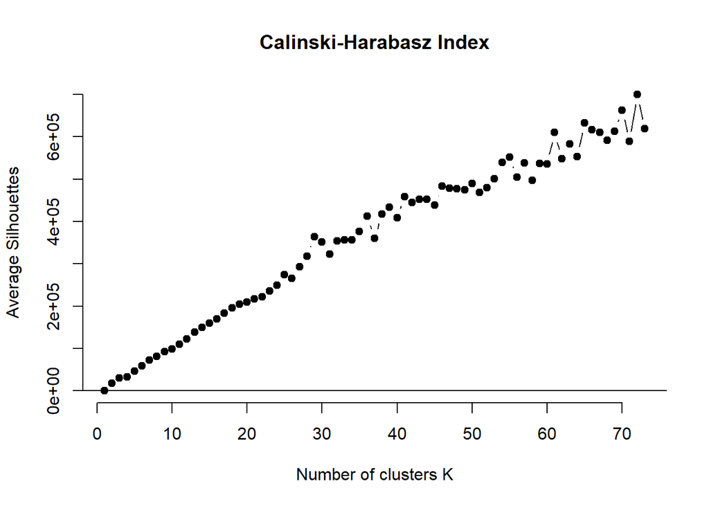

```
## integer(0)
```

```r
#Calinski-Harabasz plot
plot(1:73, fit_ch$crit,
     main = "Calinski-Harabasz Index",
     type = "b", pch = 19, frame = FALSE,
     xlab = "Number of clusters K",
     ylab = "Average Silhouettes") +
abline(h = (fit_ch$bestk))
```

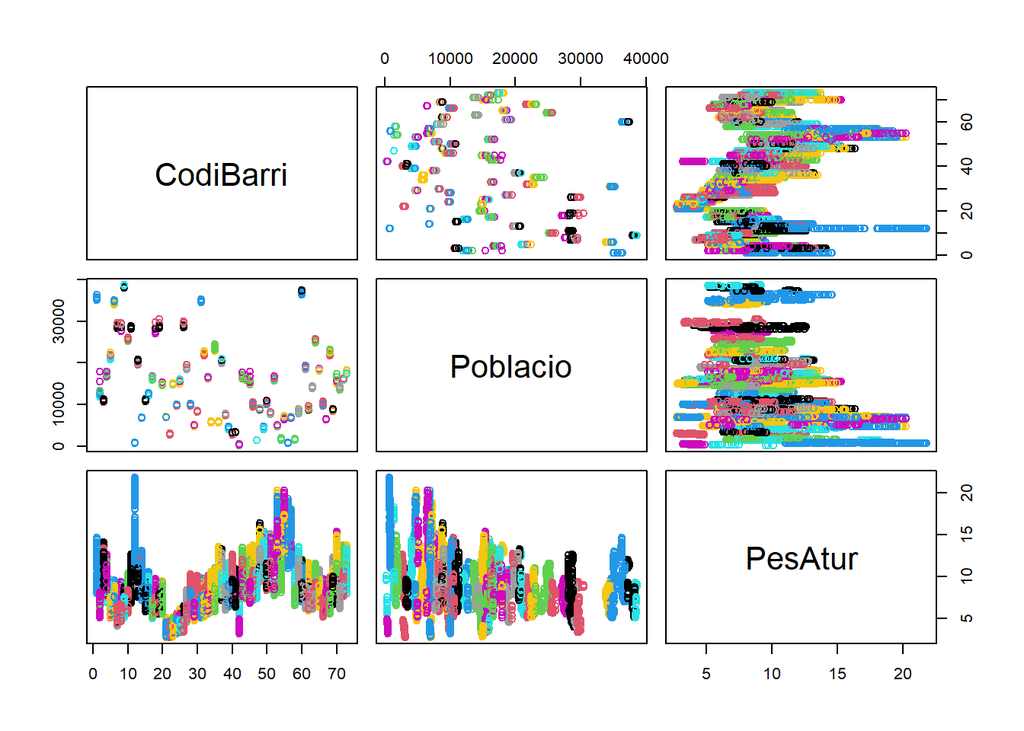

```r
#Clusters distribution plot
plot(barriPoblAtur, col=fit_ch$cluster)
```

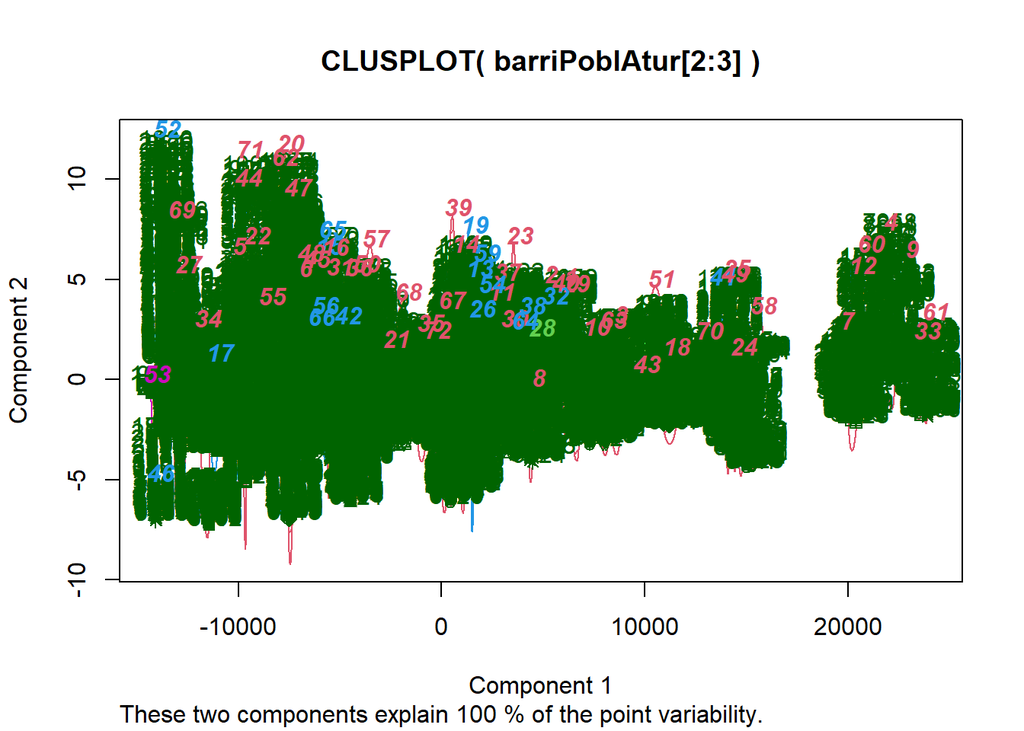

```r
clusplot(barriPoblAtur[2:3], fit_ch$cluster, color=TRUE, shade=TRUE,labels=2, lines=0)
```

*Warning: Aquest valor és variable degut al fet que ens trobem executant l’algorisme kmeans que té un factor aleatori.*

Tot i el que hem matisat anteriorment, el valor que més s’ha repetit durant el llarg de les execucions és 73.

Així doncs, donat que el resultat d’aquest criteri és molt similar a l’anterior, podem afirmar que amb l’ús de mètodes d’agregació no supervisats basats en el càlcul dels centroides, trobem que el nombre de clústers dins del nostre conjunt de dades es troba directament relacionat amb la quantitat de barris, és a dir, un clúster per a cada barri.

### 5.2.3 Average Silhouette Method - Different Metrics

A continuació treballarem amb el mateix mètode de la silueta mitjana, pero canviarem la mètrica del càlcul de la distància de l’algorisme **k-means**. Per defecte aquest utilitza la distància euclidiana.

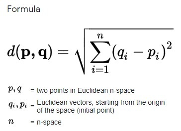

Euclidean Distance

#### 5.2.3.1 Canberra Distance

Utilitzant la llibreria **‘amap’** podem modificar la mesura de distància utilitzada dins del nostre algorisme **k-means** entre dos punts. A continuació modificarem aquesta paràmetre i utilitzarem la ‘Canberra Distance’ definida de la següent manera:

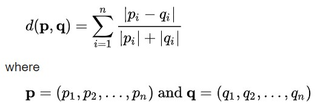

Canberra Distance

```r
#Loading library
# https://www.rdocumentation.org/packages/amap/versions/0.8-18/topics/Kmeans
# https://rdrr.io/cran/amap/man/dist.html
if(!require(amap)) install.packages("amap"); library(amap)

# Compute and plot wss for k = 2 to k = 73
k.values <- 2:73
result <- rep(0,73)
# Extract avg silhouette for 2-73 clusters
for( i in k.values ){
  km.res <- Kmeans(barriPoblAtur[1:3], centers = i, method = "canberra")
  sk <- silhouette(km.res$cluster, dist(barriPoblAtur[1:3]))
  result[i]<-mean(sk[, 2])
}
#Print max value
print(max(result))
```

```
## [1] 39.50265
```

```r
#Print the index of max value
which.max(result)
```

```
## [1] 72
```

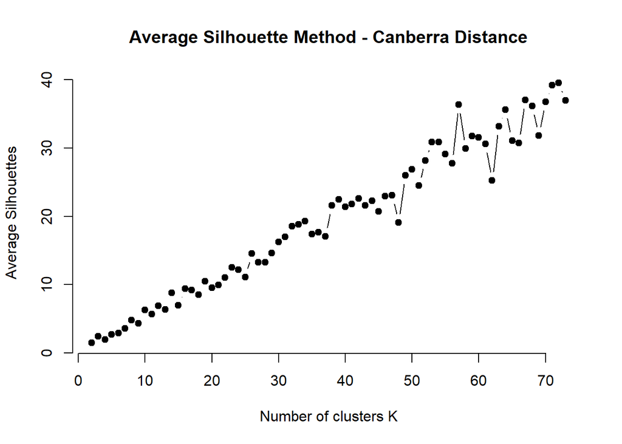

```r
#Plot Average Silhouette - Canberra Distance
plot(2:73, result[2:73],
     type = "b", pch = 19, frame = FALSE,
     main = "Average Silhouette Method - Canberra Distance",
     xlab = "Number of clusters K",
     ylab = "Average Silhouettes")
```

*Warning: Aquest valor és variable degut al fet que ens trobem executant l’algorisme kmeans que té un factor aleatori.*

Els resultats obtinguts ens indiquen que tot i que haver modificat el mètode del càlcul de la distància, obtenim un resultat pràcticament igual. Així doncs, les conclusions extretes anteriorment queden reforçades.

Per altra banda, una altra manera de comprovar la validesa de les conclusions extretes és aplicar mètodes i algorismes de clustering que formen part d’alguna altra família com pot ser el Mètode d’agrupaments jeràrquics.

## 5.3 Regles d’associació

Les regles d’associació són mètodes que ens permeten trobar i descobrir relacions/dependències entre variables dins un domini mitjançant una expressió lògica.

A continuació comentarem un conjunt de regles d’associació que podem trobar dins el nostre data set i posteriorment les computarem per veure si les previsions prèvies tenien sentit o no. El nostre estudi de mineria de dades es troba enfocat en analitzar la relació que trobem entre la població laboralment activa de la ciutat de Barcelona i l’atur amb dades segmentades en districtes i barris. Així doncs podem plantejar que les zones més castigades per l’atur durant els últims anys són aquelles que disposen de menys recursos. Situant-nos sobre el mapa de la ciutat de Barcelona, els barris que tendeixen a reflectir aquestes característiques, són les zones més antigues i a la vegada, els barris que es troben als districtes més propers a la zona del Besòs.

### 5.3.1 Còmput de les regles d’associació

Inicialment podem provar d’analitzar tot el conjunt de dades numèriques a veure quines són les regles generades i si aquestes ens aporten algun tipus d’informació.

```r
#Loading libraries
if (!require('arules')) install.packages('arules'); library('arules')

#Numeric raw data
numericData_rules <- apriori(numericData, parameter = list(support = 0.01, confidence = 0.5))
```

```
## Apriori
##
## Parameter specification:
##  confidence minval smax arem  aval originalSupport maxtime support minlen
##         0.5    0.1    1 none FALSE            TRUE       5    0.01      1
##  maxlen target  ext
##      10  rules TRUE
##
## Algorithmic control:
##  filter tree heap memopt load sort verbose
##     0.1 TRUE TRUE  FALSE TRUE    2    TRUE
##
## Absolute minimum support count: 81
##
## set item appearances ...[0 item(s)] done [0.00s].
## set transactions ...[18 item(s), 8103 transaction(s)] done [0.00s].
## sorting and recoding items ... [18 item(s)] done [0.00s].
## creating transaction tree ... done [0.00s].
## checking subsets of size 1 2 3 4 5 6 done [0.00s].
## writing ... [1475 rule(s)] done [0.00s].
## creating S4 object  ... done [0.00s].
```

```r
summary(numericData_rules)
```

```
## set of 1475 rules
##
## rule length distribution (lhs + rhs):sizes
##   2   3   4   5   6
##  17 183 680 533  62
##
##    Min. 1st Qu.  Median    Mean 3rd Qu.    Max.
##   2.000   4.000   4.000   4.298   5.000   6.000
##
## summary of quality measures:
##     support          confidence        coverage            lift
##  Min.   :0.01012   Min.   :0.5000   Min.   :0.01012   Min.   :1.217
##  1st Qu.:0.01407   1st Qu.:0.5993   1st Qu.:0.01851   1st Qu.:1.793
##  Median :0.02098   Median :0.7670   Median :0.02875   Median :2.361
##  Mean   :0.03229   Mean   :0.7765   Mean   :0.04414   Mean   :2.316
##  3rd Qu.:0.03690   3rd Qu.:1.0000   3rd Qu.:0.04739   3rd Qu.:2.779
##  Max.   :0.34247   Max.   :1.0000   Max.   :0.41096   Max.   :3.476
##      count
##  Min.   :  82.0
##  1st Qu.: 114.0
##  Median : 170.0
##  Mean   : 261.6
##  3rd Qu.: 299.0
##  Max.   :2775.0
##
## mining info:
##         data ntransactions support confidence
##  numericData          8103    0.01        0.5
```

```r
inspect(head(sort(numericData_rules, decreasing = TRUE, by = "confidence"), 10))
```

```
##      lhs                               rhs                       support confidence   coverage     lift count
## [1]  {CodiDistricte=[1,5)}          => {CodiBarri=[1,25)}     0.28767123          1 0.28767123 3.041667  2331
## [2]  {CodiBarri=[49,73]}            => {CodiDistricte=[8,10]} 0.34246575          1 0.34246575 2.433333  2775
## [3]  {Mes=[1,4),
##       CodiDistricte=[1,5)}          => {CodiBarri=[1,25)}     0.07774898          1 0.07774898 3.041667   630
## [4]  {Mes=[1,4),
##       CodiBarri=[49,73]}            => {CodiDistricte=[8,10]} 0.09255831          1 0.09255831 2.433333   750
## [5]  {CodiDistricte=[1,5),
##       PesAtur=[2.7,7.4)}            => {CodiBarri=[1,25)}     0.10971245          1 0.10971245 3.041667   889
## [6]  {Any=[2012,2015),
##       CodiDistricte=[1,5)}          => {CodiBarri=[1,25)}     0.09329878          1 0.09329878 3.041667   756
## [7]  {Any=[2015,2018),
##       CodiDistricte=[1,5)}          => {CodiBarri=[1,25)}     0.09329878          1 0.09329878 3.041667   756
## [8]  {Mes=[4,8),
##       CodiDistricte=[1,5)}          => {CodiBarri=[1,25)}     0.09329878          1 0.09329878 3.041667   756
## [9]  {CodiDistricte=[1,5),
##       Poblacio=[8.66e+03,1.68e+04)} => {CodiBarri=[1,25)}     0.08478341          1 0.08478341 3.041667   687
## [10] {CodiDistricte=[1,5),
##       Poblacio=[257,8.66e+03)}      => {CodiBarri=[1,25)}     0.04109589          1 0.04109589 3.041667   333
```

Observem que obtenim un total de 1475 regles, una xifra completament desorbitada. Així doncs, podem concloure que amb aquestes regles no podem extreure gens d’informació.

A continuació farem un anàlisi de les regles filtrant les dades de població i atur per districte, i seguidament per barri.

```r
#Filtering data by Districte - distPoblAtur
distPoblAturNames <- c("CodiDistricte", "Poblacio", "PesAtur")
distPoblAtur <- select(numericData, distPoblAturNames)

###pobAturDistricte
PobAturDistricte_rules <- apriori(distPoblAtur, parameter = list(support = 0.01, confidence = 0.5))
```

```
## Apriori
##
## Parameter specification:
##  confidence minval smax arem  aval originalSupport maxtime support minlen
##         0.5    0.1    1 none FALSE            TRUE       5    0.01      1
##  maxlen target  ext
##      10  rules TRUE
##
## Algorithmic control:
##  filter tree heap memopt load sort verbose
##     0.1 TRUE TRUE  FALSE TRUE    2    TRUE
##
## Absolute minimum support count: 81
##
## set item appearances ...[0 item(s)] done [0.00s].
## set transactions ...[9 item(s), 8103 transaction(s)] done [0.00s].
## sorting and recoding items ... [9 item(s)] done [0.00s].
## creating transaction tree ... done [0.00s].
## checking subsets of size 1 2 3 done [0.00s].
## writing ... [18 rule(s)] done [0.00s].
## creating S4 object  ... done [0.00s].
```

```r
summary(PobAturDistricte_rules)
```

```
## set of 18 rules
##
## rule length distribution (lhs + rhs):sizes
##  2  3
##  5 13
##
##    Min. 1st Qu.  Median    Mean 3rd Qu.    Max.
##   2.000   2.250   3.000   2.722   3.000   3.000
##
## summary of quality measures:
##     support          confidence        coverage            lift
##  Min.   :0.02147   Min.   :0.5045   Min.   :0.04110   Min.   :1.246
##  1st Qu.:0.06121   1st Qu.:0.5266   1st Qu.:0.09117   1st Qu.:1.581
##  Median :0.07448   Median :0.5724   Median :0.12205   Median :1.715
##  Mean   :0.10118   Mean   :0.5987   Mean   :0.17347   Mean   :1.732
##  3rd Qu.:0.14492   3rd Qu.:0.6768   3rd Qu.:0.27110   3rd Qu.:1.833
##  Max.   :0.22140   Max.   :0.7540   Max.   :0.41096   Max.   :2.367
##      count
##  Min.   : 174.0
##  1st Qu.: 496.0
##  Median : 603.5
##  Mean   : 819.9
##  3rd Qu.:1174.2
##  Max.   :1794.0
##
## mining info:
##          data ntransactions support confidence
##  distPoblAtur          8103    0.01        0.5
```

```r
inspect(PobAturDistricte_rules)
```

```
##      lhs                               rhs                               support confidence   coverage     lift count
## [1]  {CodiDistricte=[1,5)}          => {Poblacio=[1.68e+04,3.86e+04]} 0.16179193  0.5624196 0.28767123 1.680415  1311
## [2]  {CodiDistricte=[5,8)}          => {PesAtur=[2.7,7.4)}            0.15599161  0.5176085 0.30136986 1.602668  1264
## [3]  {Poblacio=[8.66e+03,1.68e+04)} => {CodiDistricte=[8,10]}         0.17030729  0.5122494 0.33246946 1.246474  1380
## [4]  {PesAtur=[9.9,21.8]}           => {CodiDistricte=[8,10]}         0.22139948  0.6497646 0.34073800 1.581094  1794
## [5]  {CodiDistricte=[8,10]}         => {PesAtur=[9.9,21.8]}           0.22139948  0.5387387 0.41095890 1.581094  1794
## [6]  {CodiDistricte=[1,5),
##       PesAtur=[2.7,7.4)}            => {Poblacio=[1.68e+04,3.86e+04]} 0.06627175  0.6040495 0.10971245 1.804798   537
## [7]  {Poblacio=[1.68e+04,3.86e+04],
##       PesAtur=[2.7,7.4)}            => {CodiDistricte=[1,5)}          0.06627175  0.5133843 0.12908799 1.784622   537
## [8]  {CodiDistricte=[1,5),
##       Poblacio=[257,8.66e+03)}      => {PesAtur=[9.9,21.8]}           0.02147353  0.5225225 0.04109589 1.533502   174
## [9]  {CodiDistricte=[1,5),
##       PesAtur=[7.4,9.9)}            => {Poblacio=[1.68e+04,3.86e+04]} 0.06688881  0.6145125 0.10884857 1.836060   542
## [10] {CodiDistricte=[5,8),
##       Poblacio=[8.66e+03,1.68e+04)} => {PesAtur=[2.7,7.4)}            0.05306677  0.6858054 0.07737875 2.123455   430
## [11] {Poblacio=[257,8.66e+03),
##       PesAtur=[2.7,7.4)}            => {CodiDistricte=[5,8)}          0.06084166  0.7134588 0.08527706 2.367386   493
## [12] {Poblacio=[257,8.66e+03),
##       PesAtur=[7.4,9.9)}            => {CodiDistricte=[5,8)}          0.04689621  0.5507246 0.08515365 1.827404   380
## [13] {CodiDistricte=[5,8),
##       PesAtur=[9.9,21.8]}           => {Poblacio=[257,8.66e+03)}      0.02924843  0.5823096 0.05022831 1.749520   237
## [14] {Poblacio=[8.66e+03,1.68e+04),
##       PesAtur=[7.4,9.9)}            => {CodiDistricte=[8,10]}         0.06232260  0.5418455 0.11501913 1.318491   505
## [15] {Poblacio=[8.66e+03,1.68e+04),
##       PesAtur=[9.9,21.8]}           => {CodiDistricte=[8,10]}         0.08206837  0.7539683 0.10884857 1.834656   665
## [16] {Poblacio=[257,8.66e+03),
##       PesAtur=[9.9,21.8]}           => {CodiDistricte=[8,10]}         0.11168703  0.6876900 0.16240898 1.673379   905
## [17] {CodiDistricte=[8,10],
##       Poblacio=[257,8.66e+03)}      => {PesAtur=[9.9,21.8]}           0.11168703  0.7216906 0.15475750 2.118022   905
## [18] {CodiDistricte=[8,10],
##       PesAtur=[9.9,21.8]}           => {Poblacio=[257,8.66e+03)}      0.11168703  0.5044593 0.22139948 1.515622   905
```

Els resultats que hem obtingut formen un conjunt de 18 regles, un nombre molt més reduït i molt més analitzable. Abans d’entrar en l’anàlisi de les regles, és necessari realitzar una taula per associar el districte amb el seu identificador, per poder realitzar una millor lectura de les dades.

Districtes (rang barris):

1. Ciutat Vella (1-4)
2. Eixample (5-10)
3. Sants - Montjuïc (11-18)
4. Les Corts (19-21)
5. Sarrià - Sant Gervasi (22-27)
6. Gràcia (28-32)
7. Horta - Guinardó (33-43)
8. Nou Barris (44-56)
9. Sant Andreu (57-63)
10. Sant Martí (64-73)

Dins el conjunt de regles, observem que certa part de les prediccions s’han complert. Les regles ens confirmen que les zones més castigades són les que es situen a la zona propera al Besòs amb un atur que se situa de forma mitjana entre el 10 i 22%. Per altra banda, les zones cèntriques i nord són les que tenen un atur mitjà molt més reduït entre el 3 i 7%. A continuació farem un anàlisi més focalitzat per barris.

```r
###pobAturBarri
PobAturBarri_rules <- apriori(barriPoblAtur, parameter = list(support = 0.01, confidence = 0.5))
```

```
## Apriori
##
## Parameter specification:
##  confidence minval smax arem  aval originalSupport maxtime support minlen
##         0.5    0.1    1 none FALSE            TRUE       5    0.01      1
##  maxlen target  ext
##      10  rules TRUE
##
## Algorithmic control:
##  filter tree heap memopt load sort verbose
##     0.1 TRUE TRUE  FALSE TRUE    2    TRUE
##
## Absolute minimum support count: 81
##
## set item appearances ...[0 item(s)] done [0.00s].
## set transactions ...[9 item(s), 8103 transaction(s)] done [0.00s].
## sorting and recoding items ... [9 item(s)] done [0.00s].
## creating transaction tree ... done [0.00s].
## checking subsets of size 1 2 3 done [0.00s].
## writing ... [12 rule(s)] done [0.00s].
## creating S4 object  ... done [0.00s].
```

```r
summary(PobAturBarri_rules)
```

```
## set of 12 rules
##
## rule length distribution (lhs + rhs):sizes
##  2  3
##  2 10
##
##    Min. 1st Qu.  Median    Mean 3rd Qu.    Max.
##   2.000   3.000   3.000   2.833   3.000   3.000
##
## summary of quality measures:
##     support          confidence        coverage            lift
##  Min.   :0.02752   Min.   :0.5023   Min.   :0.05479   Min.   :1.553
##  1st Qu.:0.05606   1st Qu.:0.5221   1st Qu.:0.10277   1st Qu.:1.560
##  Median :0.06658   Median :0.5437   Median :0.12063   Median :1.644
##  Mean   :0.08760   Mean   :0.5722   Mean   :0.15432   Mean   :1.717
##  3rd Qu.:0.10453   3rd Qu.:0.6170   3rd Qu.:0.16710   3rd Qu.:1.847
##  Max.   :0.18117   Max.   :0.7410   Max.   :0.34247   Max.   :2.175
##      count
##  Min.   : 223.0
##  1st Qu.: 454.2
##  Median : 539.5
##  Mean   : 709.8
##  3rd Qu.: 847.0
##  Max.   :1468.0
##
## mining info:
##           data ntransactions support confidence
##  barriPoblAtur          8103    0.01        0.5
```

```r
inspect(PobAturBarri_rules)
```

```
##      lhs                               rhs                               support confidence   coverage     lift count
## [1]  {PesAtur=[9.9,21.8]}           => {CodiBarri=[49,73]}            0.18116747  0.5316914 0.34073800 1.552539  1468
## [2]  {CodiBarri=[49,73]}            => {PesAtur=[9.9,21.8]}           0.18116747  0.5290090 0.34246575 1.552539  1468
## [3]  {Poblacio=[8.66e+03,1.68e+04),
##       PesAtur=[2.7,7.4)}            => {CodiBarri=[1,25)}             0.05701592  0.5250000 0.10860175 1.596875   462
## [4]  {CodiBarri=[1,25),
##       Poblacio=[8.66e+03,1.68e+04)} => {PesAtur=[2.7,7.4)}            0.05701592  0.5082508 0.11218067 1.573694   462
## [5]  {CodiBarri=[1,25),
##       Poblacio=[257,8.66e+03)}      => {PesAtur=[2.7,7.4)}            0.02752067  0.5022523 0.05479452 1.555120   223
## [6]  {Poblacio=[1.68e+04,3.86e+04],
##       PesAtur=[2.7,7.4)}            => {CodiBarri=[1,25)}             0.06627175  0.5133843 0.12908799 1.561544   537
## [7]  {Poblacio=[257,8.66e+03),
##       PesAtur=[2.7,7.4)}            => {CodiBarri=[25,49)}            0.04738986  0.5557164 0.08527706 1.690304   384
## [8]  {CodiBarri=[1,25),
##       PesAtur=[7.4,9.9)}            => {Poblacio=[1.68e+04,3.86e+04]} 0.06688881  0.6145125 0.10884857 1.836060   542
## [9]  {Poblacio=[257,8.66e+03),
##       PesAtur=[7.4,9.9)}            => {CodiBarri=[25,49)}            0.05319018  0.6246377 0.08515365 1.899940   431
## [10] {Poblacio=[257,8.66e+03),
##       PesAtur=[9.9,21.8]}           => {CodiBarri=[49,73]}            0.10452919  0.6436170 0.16240898 1.879362   847
## [11] {CodiBarri=[49,73],
##       Poblacio=[257,8.66e+03)}      => {PesAtur=[9.9,21.8]}           0.10452919  0.7410324 0.14105887 2.174786   847
## [12] {CodiBarri=[49,73],
##       PesAtur=[9.9,21.8]}           => {Poblacio=[257,8.66e+03)}      0.10452919  0.5769755 0.18116747 1.733494   847
```

## 5.4 Model predictiu

En aquest apartat generarem un model predictiu basat en arbres de decisió per tal de predir nous valors d’entrada, i poder-los classificar seguint les regles del nostre conjunt de dades actual. Inicialment realitzarem la divisió del conjunt de dades entre el conjunt d’entrenament i el conjunt de test. El conjunt d’entrenament ens permetrà entrenar el nostre model, mentre que el conjunt de test, ens permetrà verificar el funcionament del model i avaluar la qualitat d’aquest.

```r
#Creating a seed
set.seed(101)
trainRows = numericRows * 0.1
#Creating training indexes
train_indexes <- sample(numericRows, trainRows)
#Create training sample
atur_train <- barriPoblAtur[train_indexes, ]
#Creating test sample
atur_test  <- barriPoblAtur[-train_indexes, ]
```

```r
#Load of C50 library
if (!require(C50)) install.packages(C50);library(C50)
#'default' to a factor
atur_train$PesAtur<-as.factor(atur_train$PesAtur)
#Model creation
model <- C50::C5.0(atur_train[-3], atur_train$PesAtur,rules = TRUE)
#Summary of the model
summary(model)
```

```
##
## Call:
## C5.0.default(x = atur_train[-3], y = atur_train$PesAtur, rules = TRUE)
##
##
## C5.0 [Release 2.07 GPL Edition]      Sun Jun 20 19:47:27 2021
## -------------------------------
##
## Class specified by attribute `outcome'
##
## Read 810 cases (3 attributes) from undefined.data
##
## Rules:
##
## Rule 1: (19/15, lift 48.2)
##  CodiBarri > 20
##  CodiBarri <= 23
##  Poblacio <= 14715
##  ->  class 2.9  [0.238]
##
## Rule 2: (3/2, lift 64.8)
##  CodiBarri > 20
##  CodiBarri <= 34
##  Poblacio <= 3078
##  ->  class 3  [0.400]
##
## Rule 3: (34/29, lift 27.0)
##  CodiBarri > 20
##  CodiBarri <= 23
##  ->  class 3  [0.167]
##
## Rule 4: (2/1, lift 101.2)
##  CodiBarri > 41
##  CodiBarri <= 43
##  Poblacio > 411
##  Poblacio <= 16032
##  ->  class 3.2  [0.500]
##
## Rule 5: (3/1, lift 162.0)
##  CodiBarri > 23
```

[output cut: 1276 more lines]

```
##    19.6        1       0       1
##    20          1       0       1
##    20.2        1       0       1
##    20.3        1       0       1
##    20.7        2       4       0
##    21.8        1       0       1
##
##
##  Attribute usage:
##
##  100.00% CodiBarri
##   81.23% Poblacio
##
##
## Time: 0.0 secs
```

Un cop hem executat el model, observem que la quantit de regles de classificació és molt gran. A continuació observarem com queda l’arbre de decisió.

[figure not shown]

```r
# #Plot the decision tree of the model
model <- C50::C5.0(atur_train[-3], atur_train$PesAtur)
plot(model)
```

```r
#Precision computation
predicted_model <- predict(model, atur_test, type="class")

summary(predicted_model)
```

```
##     5.8     8.8     8.5     7.9    10.3     5.3     5.5     9.9     8.7    12.1
##     323     239     222     219     216     205     201     190     186     186
##    10.8     7.7     5.6     8.4     4.7     6.7     6.3       8      12    10.6
##     185     162     156     155     142     135     127     127     122     121
##    10.7    11.9      13     6.2     6.1     6.6      10     2.9    12.8     8.3
##     117     111     109     108     104     100     100      93      92      89
##     9.1       3    11.8     8.2     8.9     9.4    12.4     7.4     9.8     9.3
##      89      88      83      79      79      78      78      76      76      75
##     7.2     7.1     4.4     3.8     6.4     6.9     7.6     3.5       9       7
##      71      70      69      68      65      63      63      62      60      54
##     8.1    11.6     3.2    10.4     6.8    19.2    12.3    17.8     3.4     4.6
##      53      52      49      46      43      43      39      34      33      33
##       5     5.2     9.5    13.8     6.5     7.3    17.7    13.5     3.3    12.7
##      33      33      33      33      32      32      32      31      30      30
##    20.7     4.9     5.4    12.6    16.2    10.5      11    15.9    19.1     7.5
##      30      22      22      22      22      21      21      21      21      20
##     7.8     9.6       4    10.1     3.6    11.2    16.1     4.3     5.7       6
##      20      20      18      17      13      13      13      10      10      10
##     9.2     9.7    11.4    11.7    13.3    18.8     5.1    10.2    11.5 (Other)
##      10      10      10      10      10      10       9       9       9       8
```

```r
if(!require(gmodels)){
  install.packages('gmodels', repos='http://cran.us.r-project.org')
  library(gmodels)
}
# Uncomment to see values
# CrossTable(atur_test$PesAtur, predicted_model,
#            prop.chisq = FALSE, prop.c = FALSE, prop.r = FALSE,
#            dnn = c('Reality', 'Predicted'))
```